# (Effects of loan characteristics on the borrower's Annual Percentage Rate )

## by (Kareem Negm )

## Investigation Overview

> In this presentation we will spread some perceptions about the characteristics of loans to see how they relate to the borrower's Annual Percentage Rate we will make visualizations on some important features such as BorrowerAPR, ProsperScore, and CreditScoreRangeUpper

## Dataset Overview

> This data set contains 113,937 loans with 81 variables on each loan, including loan amount, borrower rate (or interest rate), current loan status, borrower income, and many others.

## (BorrowerAPR values Distribution)

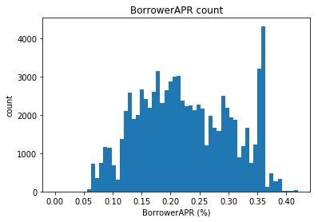

```python
bins = np.arange(0, df2['BorrowerAPR'].max(), 0.007)
plt.hist(data = df2, x = 'BorrowerAPR', bins = bins)
plt.title('BorrowerAPR count')
plt.xlabel('BorrowerAPR (%)')
plt.ylabel('count')
plt.xticks(np.arange(0, df2['BorrowerAPR'].max(), 0.05));
```

## (BorrowerAPR & ProsperScore)

people with a higher rating tend to be more reliable and therefore get a lower interest rate for the borrower. That's what we figured out in the drawing below.

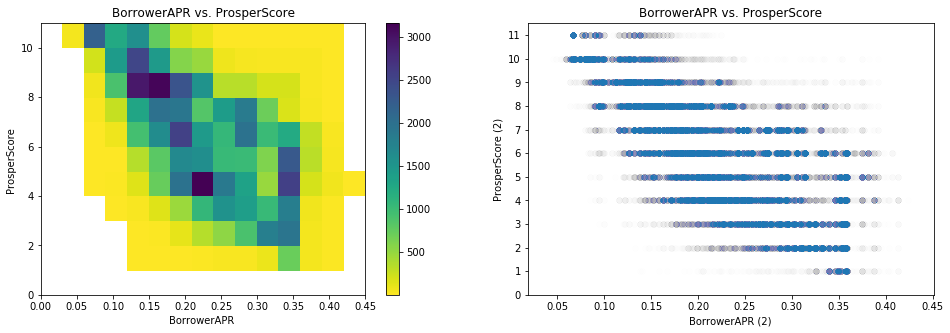

```python
plt.figure(figsize = [16, 5])


plt.subplot(1, 2, 1)
bins_x = np.arange(0, df2['BorrowerAPR'].max()+0.05, 0.03)
bins_y = np.arange(0, df2['ProsperScore'].max()+1, 1)
plt.hist2d(data = df2, x = 'BorrowerAPR', y = 'ProsperScore', bins = [bins_x, bins_y],
               cmap = 'viridis_r', cmin = 0.5)
plt.colorbar()
plt.title('BorrowerAPR vs. ProsperScore')
plt.xlabel('BorrowerAPR ')
plt.ylabel('ProsperScore ');


plt.subplot(1, 2, 2)
plt.scatter(data = df2, x = 'BorrowerAPR', y = 'ProsperScore', alpha =  0.005)
plt.yticks(np.arange(0, 12, 1))

plt.title('BorrowerAPR vs. ProsperScore')
plt.xlabel('BorrowerAPR (2)')
plt.ylabel('ProsperScore (2)');
```

## (BorrowerAPR & ProsperScore & CreditScoreRangeUpper)

We can see the creditScoreRangeUpper rise with the borrowerAPR fall in parcels. By adding ProsperScore to the colour encodings, the BorrowerAPR decreases as the ProsperScore rise. This proves that CreditScoreRangeUpper and ProsperScore are adversely correlated with BorrowerAPR.

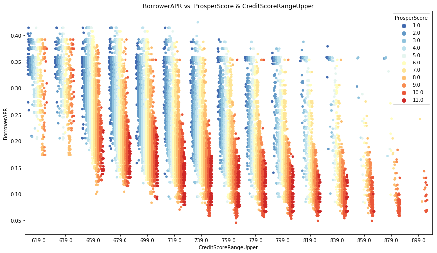

```python
plt.figure(figsize = [14.7, 8.27])
sb.stripplot(data = df2, x = 'CreditScoreRangeUpper', y = 'BorrowerAPR', hue ='ProsperScore', jitter = 0.35 , dodge = True , palette ="RdYlBu_r")
plt.title('BorrowerAPR vs. ProsperScore & CreditScoreRangeUpper')
plt.xlabel('CreditScoreRangeUpper')
plt.ylabel('BorrowerAPR');
```